# amazon_stock_and_price_movement_pred(in progress)

## Introduction(in progress)

Hello everyone, My name is Arnab Dey Sarkar. I am a PhD student in math and a newcomer in Data Science. Later in my research I got really interested in Quant and I am learning quant related topics; **Time Series** is one of that. This is my first take on **Time Series** model. I will try to predict the future closing price of amazon stock. In the begining I will use

- Time Series model.

#### Data Source:

I have taken the data from Kaggle **Amazon Stock Price And Movement Prediction** "https://www.kaggle.com/code/aenes95/amazon-stock-price-and-movement-prediction"

The reason for choosing this dataset is that I will also try to use models at the end like

- Linear Regression (LR)
- Support Vector Machines (SVR, SVC)
- Long Short Term Memory (LSTM)

I'll try to keep it simple in this notebook.

### Dataset Description:

This dataset contains some of technical indicators (The value of period is taken as 14), some of exchange rates (based on usd), financial indexes of America (Dow_Jones, NASDAQ, S&P_500) and the last one is daily Google Trends data. Google Trends is a tool to provide to know number of searches for a word (or a term) on the internet.

### Methodology:

Our goal is to predicting stock movement rather than stock prices. We can do this in two ways:

First way is apply a regression method in our data and predict a time series that try to mimic target values. Then we compare their daily movements between our predicted signal and real signal.

Secondly, the method can be done with classification or regression. This time our target is price movement and it is a boolean value. If it is true, close price's of company will increase tomorrow. If it is false, it will decrease. If you use a classifier there is no problem. Output is always a boolean value but if you do with the regression, output value is a number between 0 and 1. In this case you can round your values to 0 or 1 and they will be your predicted class values.

And then we will do optimization or feature selection to some of our models for improve our accuracies.

```python
import pandas as pd
import math
import numpy as np
import datetime

import matplotlib.pyplot as plt

import time

from sklearn import linear_model
from sklearn.model_selection import train_test_split
from sklearn.metrics import accuracy_score

from sklearn import svm
from sklearn import preprocessing
from sklearn.preprocessing import StandardScaler

from sklearn.neural_network import MLPClassifier
```

```python
import tensorflow as tf
from tensorflow.keras.models import Sequential
from tensorflow.keras.layers import Dense, Dropout, LSTM

from sklearn.metrics import r2_score
```

```python
df1 = pd.read_csv("amazon_trends.csv")
df2 = pd.read_csv("mydata.csv")
```

```python
df1.shape
```

```
(5435, 2)
```

```python
df2.shape
```

```
(3552, 36)
```

```python
%%capture
df2.info()
```

```python
df = pd.merge(df2, df1, on = "Date", how = "inner")
```

```python
df.shape
```

```
(3552, 37)
```

```python
%%capture
df1.columns
```

```python
df2.columns
```

```
Index(['Date', 'Open', 'High', 'Low', 'Close', 'Volume', 'Dividends',
       'Stock Splits', 'Gain', 'Loss', 'Avg_Gain', 'Avg_Loss', 'RSI', 'SMA',
       'EMA', 'MACD', 'Bollinger_Upper', 'Bollinger_Lower', 'ROC', 'PVT',
       'Usd_Eur_Close', 'Usd_Chf_Close', 'Usd_Gbp_Close', 'Usd_Jpy_Close',
       'Usd_Cad_Close', 'Usd_Inf_Close', 'Usd_Rub_Close', 'Usd_Try_Close',
       'IRX_Close', 'JPM_Close', 'BAC_Close', 'Citigroup_Close', 'WFC_Close',
       'NASDAQ_Close', 'SP_500_Close', 'Dow_Jones_Close'],
      dtype='object')
```

### Explanation of Column Variables:

1. **Date**: The date of the trading day.
2. **Open**: The price at which the stock opened for trading on a particular day.
3. **High**: The highest price the stock reached during the trading day.
4. **Low**: The lowest price the stock reached during the trading day.
5. **Close**: The price at which the stock closed at the end of the trading day.
6. **Volume**: The number of shares traded during the day.
7. **Dividends**: The dividend paid per share on that date.
8. **Stock Splits**: The ratio of any stock split that occurred on that date.
9. **Gain**: The daily gain of the stock price (possibly calculated as Close - Open).
10. **Loss**: The daily loss of the stock price (possibly calculated as Open - Close).
11. **Avg_Gain**: The average gain over a specified period.
12. **Avg_Loss**: The average loss over a specified period.
13. **RSI**: Relative Strength Index, a momentum oscillator that measures the speed and change of price movements.
14. **SMA**: Simple Moving Average, the average of the stock price over a specific number of periods.
15. **EMA**: Exponential Moving Average, a type of moving average that places a greater weight and significance on the most recent data points.
16. **MACD**: Moving Average Convergence Divergence, a trend-following momentum indicator.
17. **Bollinger_Upper**: The upper band of the Bollinger Bands, which is a volatility indicator.
18. **Bollinger_Lower**: The lower band of the Bollinger Bands.
19. **ROC**: Rate of Change, a momentum oscillator that measures the percentage change in price between the current price and the price n periods ago.
20. **PVT**: Price Volume Trend, a technical analysis indicator that relates price and volume to identify the strength of price movements.
21. **Usd_Eur_Close**: The closing price of the USD to EUR exchange rate.
22. **Usd_Chf_Close**: The closing price of the USD to CHF exchange rate.
23. **Usd_Gbp_Close**: The closing price of the USD to GBP exchange rate.
24. **Usd_Jpy_Close**: The closing price of the USD to JPY exchange rate.
25. **Usd_Cad_Close**: The closing price of the USD to CAD exchange rate.
26. **Usd_Inf_Close**: The closing price of the USD to INR (Indian Rupee) exchange rate.
27. **Usd_Rub_Close**: The closing price of the USD to RUB (Russian Ruble) exchange rate.
28. **Usd_Try_Close**: The closing price of the USD to TRY (Turkish Lira) exchange rate.
29. **IRX_Close**: The closing price of the 13-week Treasury Bill.
30. **JPM_Close**: The closing price of JPMorgan Chase & Co. stock.
31. **BAC_Close**: The closing price of Bank of America Corporation stock.
32. **Citigroup_Close**: The closing price of Citigroup Inc. stock.
33. **WFC_Close**: The closing price of Wells Fargo & Company stock.
34. **NASDAQ_Close**: The closing value of the NASDAQ Composite Index.
35. **SP_500_Close**: The closing value of the S&P 500 Index.
36. **Dow_Jones_Close**: The closing value of the Dow Jones Industrial Average.

These variables represent both stock-specific metrics and broader financial indicators, which can be used for various types of financial analysis, including time series analysis and regression modeling.

```python
%%capture
df.columns
```

## Time Series

```python
import matplotlib.pyplot as plt #Plotting
%matplotlib inline
import seaborn as sns
plt.rcParams["figure.figsize"] = (10,10) #Make the plots bigger by default
plt.rcParams["lines.linewidth"] = 2 #Setting the default line width
plt.style.use("ggplot")


# from statsmodels.tsa.seasonal import seasonal_decompose #Describes the time data
from statsmodels.tsa.stattools import adfuller #Check if data is stationary
from statsmodels.graphics.tsaplots import plot_acf #Compute lag for ARIMA
from statsmodels.graphics.tsaplots import plot_pacf #Compute partial lag for ARIMA
from statsmodels.tsa.arima_model import ARIMA #Predictions and Forecasting
import statsmodels.api as sm


from sklearn.preprocessing import MinMaxScaler
from datetime import datetime
from statsmodels.tsa.holtwinters import SimpleExpSmoothing
from statsmodels.tsa.holtwinters import ExponentialSmoothing
from keras.models import Sequential
from keras.layers import Dense, LSTM
from keras.callbacks import ModelCheckpoint, EarlyStopping , ReduceLROnPlateau
from sklearn.metrics import mean_absolute_error
```

```python
close_df = df2[["Date", "Close"]].copy()
```

```python
close_df.dtypes
```

```
Date      object
Close    float64
dtype: object
```

```python
close_df["Date"] = pd.to_datetime(close_df["Date"])
close_df.set_index("Date", inplace = True)
```

```python
close_df.dtypes
```

```
Close    float64
dtype: object
```

Setting up the every day frequency.

```python
close_df = close_df.asfreq("d")
```

```python
close_df.isna().sum()
```

```
Close    1793
dtype: int64
```

```python
close_df.tail()
```

[output not shown]

```python
close_df = close_df.fillna(method  = "bfill")
```

```python
close_df.isna().sum()
```

```
Close    0
dtype: int64
```

```python
close_df.info()
```

```
<class 'pandas.core.frame.DataFrame'>
DatetimeIndex: 5345 entries, 2005-01-03 to 2019-08-22
Freq: D
Data columns (total 1 columns):
 #   Column  Non-Null Count  Dtype
---  ------  --------------  -----
 0   Close   5345 non-null   float64
dtypes: float64(1)
memory usage: 83.5 KB
```

```python
close_df.describe()
```

|  | Close |
| --- | --- |
| count | 5345.000000 |
| mean | 438.359023 |
| std | 522.582372 |
| min | 26.070000 |
| 25% | 78.170000 |
| 50% | 220.070000 |
| 75% | 579.870000 |
| max | 2039.510000 |

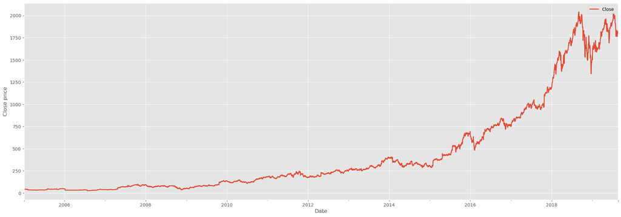

```python
close_df.plot(figsize=(24,8))
plt.ylabel("Close price")
plt.grid(True)
```

As we had large magnitude of variation in the closed stock prices, we are using **multiplicative time series** model.

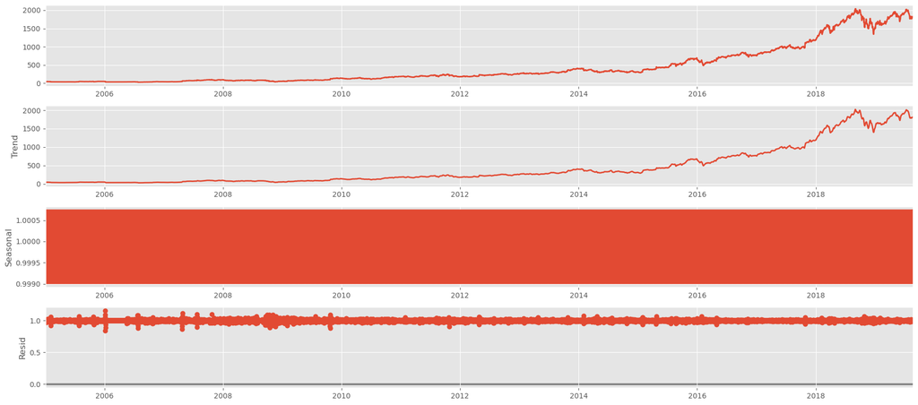

```python
my_decomposition = sm.tsa.seasonal_decompose(close_df, model='mulplicative')

plt.rcParams['figure.figsize'] = 18,8
plt.show()

fig = my_decomposition.plot()
```

We can't see any particular seasonal pattern but it doesn't mean that the pattern is not there. We have daily frequency over 14 years. Hence, the pattern is congested in the picture. I have transformed the data with month frequency in part 1 ipynb. You can see the pattern there.

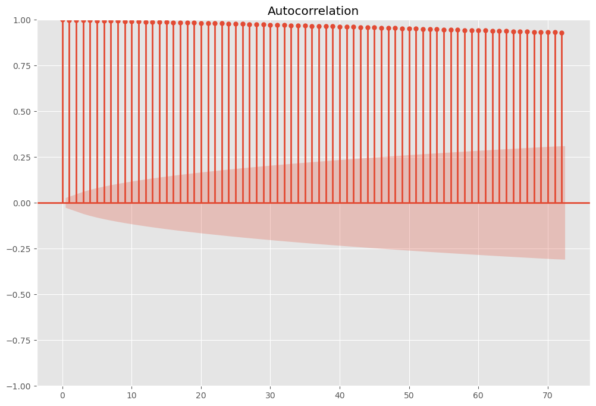

```python
fig, ax = plt.subplots( figsize = (12, 8) )

sm.graphics.tsa.plot_acf( close_df.values.squeeze(), lags=72, ax = ax)

plt.show()
```

```python
%%capture

lags_use = [1, 3, 6, 9, 12, 15, 18, 21, 24]

fig, ax = plt.subplots(3, 3, figsize=(12, 12), sharex=True, sharey=True)

ax = ax.ravel()

for k in range(len(lags_use)):
    pd.plotting.lag_plot( close_df, lag=lags_use[k], ax=ax[k] )
    ax[k].plot( ax[k].get_xlim(), ax[k].get_ylim(), 'k--')
    ax[k].set_title('lag: ' + str(lags_use[k]) )

plt.show()
```

```python
df_decomp = pd.DataFrame({'observed': my_decomposition.observed,
                          'seasonal_adjusted': my_decomposition.observed - my_decomposition.seasonal},
                        index=close_df.index)
```

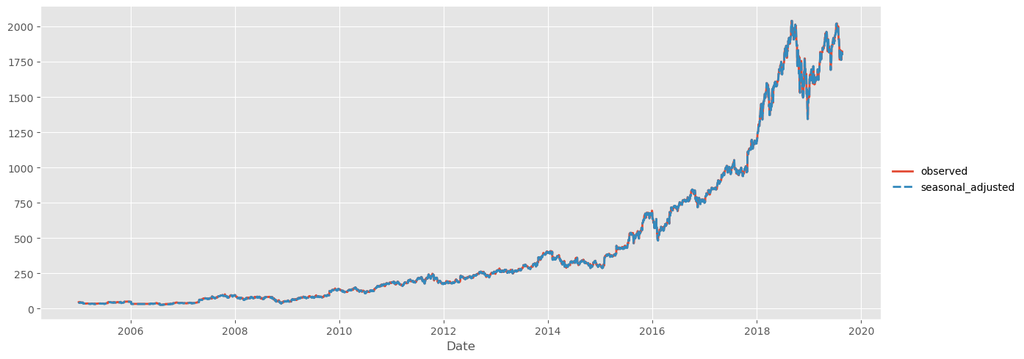

```python
sns.relplot( data = df_decomp, kind='line', aspect=2.5 )

plt.show()
```

As the data is very condensed we won't be able to see a seperate seasonal adjusted from observed. Hence, lets zoom on some portion.

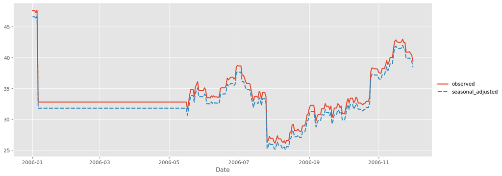

```python
df_filtered = df_decomp.loc['2006-01-01':'2006-12-01', ['observed', 'seasonal_adjusted']]

# Plot using seaborn's relplot
sns.relplot(data=df_filtered, kind='line', aspect=2.5)

# Show the plot
plt.show()
```

##### Analysis of the Observed and Seasonally Adjusted Data for 2006:

Now lets focus on the end part of the data in 2019.

```python
# close_df.index.year
```

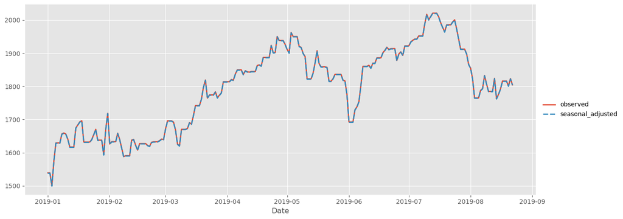

```python
df_filtered1 = df_decomp.loc['2019-01-01':'2019-12-01', ['observed', 'seasonal_adjusted']]

# Plot using seaborn's relplot
sns.relplot(data=df_filtered1, kind='line', aspect=2.5)

# Show the plot
plt.show()
```

## Time Series Model:

From now on our objective will be to choose different models. Test their accuracy and predict/forecasting using the top 2 models. I will skip the basic one which are Naive and average and start with:

1) Seasonal Naive.

2) ARIMA

3) LSTM